# Divvy OD Flows: 2 km Aggregation and Clock-Hour Pooling

Reproducible R example

2026-11-05

## Purpose

This report reproduces the supplied **2 km Divvy aggregation** and pools the same clock hours across all January 2026 dates. The selected window is **00:00–03:00 in America/Chicago**. It uses `traffic_od_map()` to validate mapped columns, call the existing `trafficmap.R` basemap method, draw directed OD connections, and display only nodes that are endpoints of a displayed route.

The five fixed flow classes are `1`, `2–3`, `4–5`, `6–7`, and `>= 8`. Flow-one routes are dashed, and every route has a solid arrowhead before its destination node.

## Read and validate the supplied 2 km data

The supplied `r2000` files are the authoritative processed inputs used by the earlier multi-scale visualization. Extra columns are allowed; only mapped identifiers, coordinates, timestamps, and counts are required.

```r
nodes <- data.table::fread(params$node_file, showProgress = FALSE)
flows <- data.table::fread(
  params$flow_file,
  showProgress = FALSE,
  colClasses = list(character = "timestamp")
)

required_node_columns <- c("node_idx", "longitude", "latitude")
required_flow_columns <- c(
  "timestamp", "origin_node_idx", "destination_node_idx", "trip_count"
)

stopifnot(
  all(required_node_columns %in% names(nodes)),
  all(required_flow_columns %in% names(flows)),
  !anyDuplicated(nodes$node_idx),
  all(flows$origin_node_idx %in% nodes$node_idx),
  all(flows$destination_node_idx %in% nodes$node_idx),
  all(is.finite(nodes$longitude)),
  all(is.finite(nodes$latitude)),
  all(flows$trip_count >= 0)
)

data.frame(
  Input = c("2 km nodes", "Hourly OD rows"),
  File = c(basename(params$node_file), basename(params$flow_file)),
  Rows = c(nrow(nodes), nrow(flows)),
  check.names = FALSE
) |>
  knitr::kable(align = c("l", "l", "r"))
```

| Input | File | Rows |
| --- | --- | --- |
| 2 km nodes | nodes_r2000.csv | 84 |
| Hourly OD rows | od_flow_2026_01_dt01h_r2000.csv | 32300 |

## Pool all dates over 00:00–03:00

`hour_window = c(0, 3)` is different from a single-date timestamp window. It selects clock hours 00, 01, and 02 from every date, then sums records with the same directed origin and destination. Self-loops remain in the summary but are not drawn as arrows.

```r
parsed_time <- as.POSIXct(flows$timestamp, tz = "America/Chicago")
clock_hour <- as.integer(format(parsed_time, "%H", tz = "America/Chicago"))
selected <- flows[
  clock_hour >= params$hour_start & clock_hour < params$hour_end,
]

pooled <- selected[
  , .(flow = sum(trip_count)),
  by = .(origin_node_idx, destination_node_idx)
]
nonloop <- pooled[origin_node_idx != destination_node_idx]

data.frame(
  Metric = c(
    "Selected trips including within-node trips",
    "Within-node trips",
    "Nonloop trips",
    "Active directed nonloop OD pairs"
  ),
  Value = c(
    sum(pooled$flow),
    sum(pooled$flow[pooled$origin_node_idx == pooled$destination_node_idx]),
    sum(nonloop$flow),
    nrow(nonloop)
  )
) |>
  knitr::kable(align = c("l", "r"))
```

| Metric | Value |
| --- | --- |
| Selected trips including within-node trips | 1826 |
| Within-node trips | 857 |
| Nonloop trips | 969 |
| Active directed nonloop OD pairs | 206 |

## Directed OD map

The map extent is calculated from active endpoints only. The Chicago street table is converted to the existing trafficmap GeoJSON basemap format before the background is drawn. Lines are drawn first, active nodes second, and visible arrowheads last.

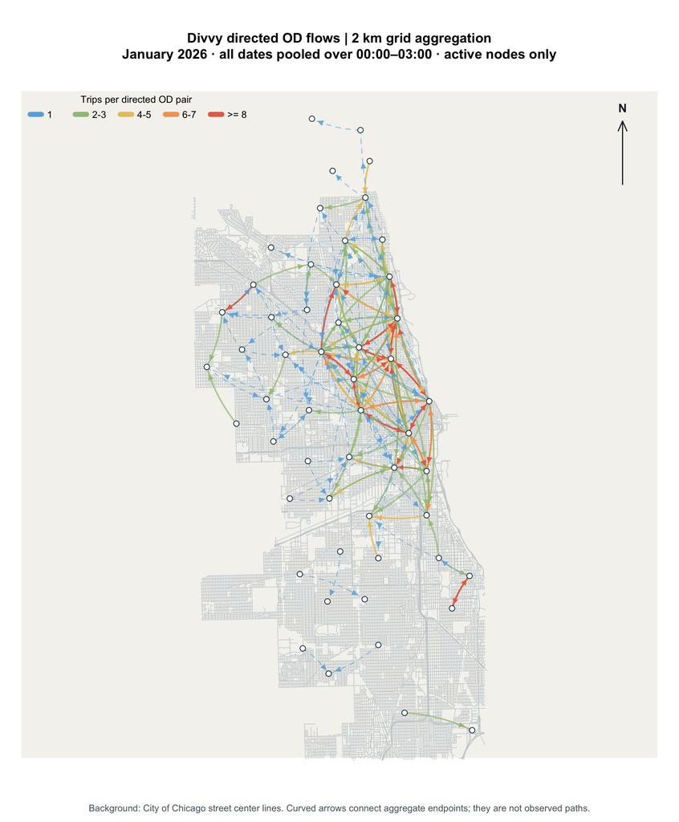

```r
map_result <- traffic_od_map(
  nodes = params$node_file,
  flows = params$flow_file,
  basemap = params$street_file,
  node_columns = c(
    id = "node_idx",
    longitude = "longitude",
    latitude = "latitude",
    size = "n_raw_stations"
  ),
  flow_columns = c(
    origin = "origin_node_idx",
    destination = "destination_node_idx",
    count = "trip_count",
    time = "timestamp"
  ),
  hour_window = c(params$hour_start, params$hour_end),
  timezone = "America/Chicago",
  top_n = Inf,
  active_nodes_only = TRUE,
  title = "Divvy directed OD flows | 2 km grid aggregation",
  subtitle = paste(
    "January 2026 · all dates pooled over 00:00–03:00 ·",
    "active nodes only"
  ),
  caption = paste(
    "Background: City of Chicago street center lines.",
    "Curved arrows connect aggregate endpoints; they are not observed paths."
  ),
  output_file = params$map_file,
  width = 7.6,
  height = 9.2,
  dpi = 240
)
```

## Displayed-network summary

```r
class_counts <- map_result$summary$flow_classes
summary_table <- data.frame(
  Metric = c(
    "Active nodes displayed",
    "Directed OD pairs displayed",
    "Nonloop trips represented",
    paste0("Flow class: ", names(class_counts))
  ),
  Value = c(
    map_result$summary$displayed_nodes,
    map_result$summary$displayed_pairs,
    map_result$summary$displayed_flow,
    unname(class_counts)
  )
)
knitr::kable(summary_table, align = c("l", "r"))
```

| Metric | Value |
| --- | --- |
| Active nodes displayed | 53 |
| Directed OD pairs displayed | 206 |
| Nonloop trips represented | 969 |
| Flow class: 1 | 84 |
| Flow class: 2-3 | 57 |
| Flow class: 4-5 | 24 |
| Flow class: 6-7 | 8 |
| Flow class: >= 8 | 33 |

## Reusing the functions with other OD data

Column mappings make the functions independent of provider-specific names. For a single absolute date interval, use `start_time` and `end_time`. To pool the same clock hours across dates, use `hour_window`.

```r
traffic_od_map(
  nodes = other_nodes,
  flows = other_flows,
  basemap = other_background,
  node_columns = c(
    id = "station", longitude = "x", latitude = "y", size = NA
  ),
  flow_columns = c(
    origin = "from_station", destination = "to_station",
    count = "rides", time = "departure_time"
  ),
  hour_window = c(0, 3),
  timezone = "America/Chicago"
)
```

Raw stations can still be converted to an arbitrary radius aggregation before mapping:

```r
aggregated <- aggregate_od_data(
  nodes = raw_nodes,
  flows = raw_flows,
  radius_m = 1000,
  node_columns = c(
    id = "station", longitude = "x", latitude = "y",
    name = "station_name", weight = NA
  ),
  flow_columns = c(
    origin = "from_station", destination = "to_station",
    count = "rides", time = "departure_time"
  ),
  timezone = "America/Chicago"
)
```

## Notes and limitations

- Every OD endpoint must match one mapped node identifier.
- `hour_window` pools matching clock hours across every date in the input.
- Only endpoints of displayed nonloop routes are shown when `active_nodes_only = TRUE`.
- Fixed flow classes make colours comparable across maps.
- OD arrows are visual connections, not observed bicycle trajectories or map-matched routes.